# Report

Vasco Ferreira

7/13/2021

This data analytics report is one the Capstone Exercises for the Google Data Analytics Course on Coursera. This case study is about a bike-sharing company that aims to increase the number of annual members (subscribers) as these type of members are the most profitable for the company.

Information about the company:

- 5800 bikes
- 600 docking stations
- different types of bikes:
  - traditional bikes
  - reclining bikes
  - hand tricycles
  - cargo bikes
- 92% of members use traditional bikes
- 8% of members use the other types of bikes
- 70% of members use bikes for leisure
- 30% of members use bikes for commuting

## Load libraries and data

```r
library(tidyverse)
library(lubridate)
library(tidyquant)
```

Define the types for the data as the parser only looks for the first rows and there is data with a new format in the later rows:

```r
col_types = list(
  col_character(),
  col_character(),
  col_datetime(),
  col_datetime(),
  col_character(),
  col_character(),
  col_character(),
  col_character(),
  col_double(),
  col_double(),
  col_double(),
  col_double(),
  col_character(),
  col_double(),
  col_double()
)
```

Load the data:

```r
tripdata <- read_csv("../data/processed/02_tripdata.csv", col_types = col_types)
```

## Ask

The task is to answer the first question of the new marketing program:

> How do annual members and casual riders use Cyclistic bikes differently?

To answer this question we need to first group the data by each member type and then calculate some basic descriptive statistics:

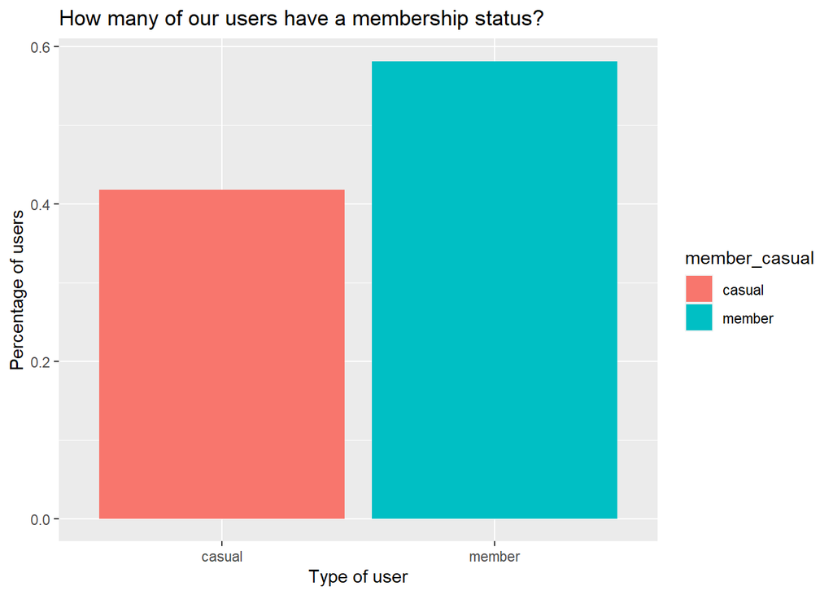

```r
tripdata %>%
  drop_na(member_casual) %>%
  ggplot() +
    geom_bar(aes(member_casual, y=stat(count/sum(count)), fill=member_casual)) +
    ylab("Percentage of users") +
    xlab("Type of user") +
    labs(title="How many of our users have a membership status?")
```

In this graph we can see that almost 60% of our users have a membership status.

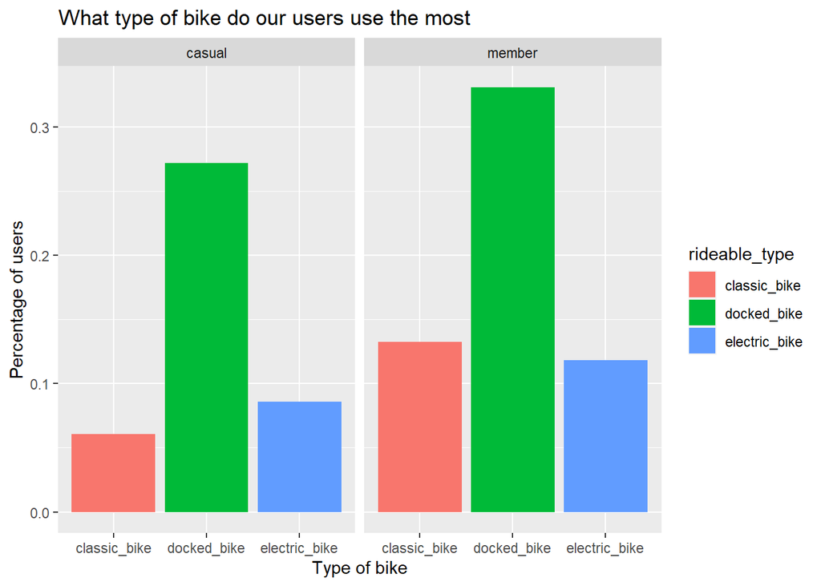

```r
tripdata %>%
  drop_na(member_casual, rideable_type) %>%
  ggplot() +
    geom_bar(aes(rideable_type, y=stat(count/sum(count)), fill=rideable_type)) +
    facet_wrap(~member_casual) +
    ylab("Percentage of users") +
    xlab("Type of bike") +
    labs(title="What type of bike do our users use the most")
```

Both types of users use the `docked bike` the most but, the `member` users use the `classic bike` more than the `electrict bike`. The ´casual´ users prefer the `electric bike` over the `classic bike`

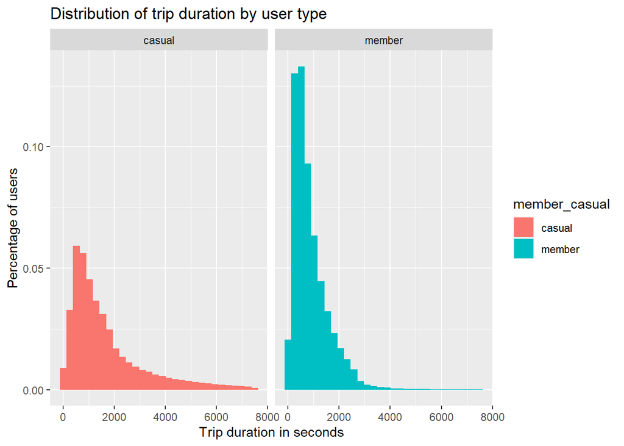

```r
tripdata %>%
  drop_na(member_casual, trip_duration) %>%
  filter(trip_duration > 0, trip_duration < 7500) %>%
  ggplot() +
    geom_histogram(aes(x=trip_duration, y = stat(count / sum(count)), fill=member_casual)) +
    facet_wrap(~member_casual) +
    ylab("Percentage of users") +
    xlab("Trip duration in seconds") +
    labs(title="Distribution of trip duration by user type")
```

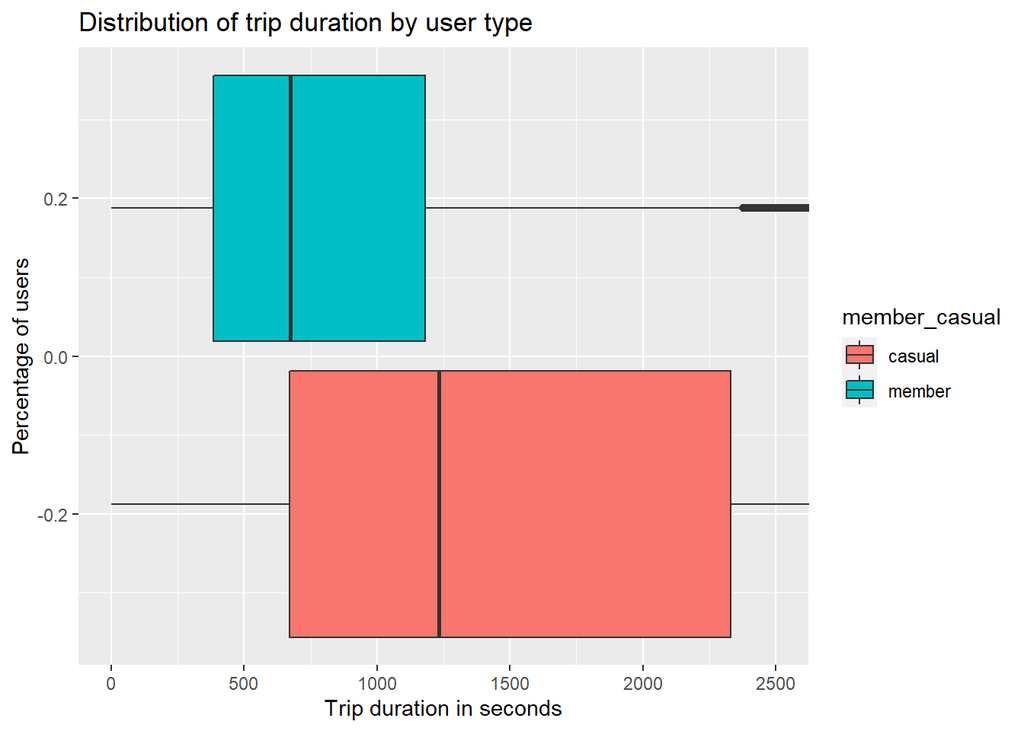

```r
tripdata %>%
  drop_na(member_casual, trip_duration) %>%
  ggplot() +
    geom_boxplot(aes(trip_duration, fill=member_casual)) +
    coord_cartesian(xlim=c(0, 2500)) +
    ylab("Percentage of users") +
    xlab("Trip duration in seconds") +
    labs(title="Distribution of trip duration by user type")
```

The average `casual` user spends the double of time of a `member` during a trip, 20 minutes versus 11 minutes. And that the trip duration is more spread out among `casual` members. This could be a demonstration of the majority of the users using bike for leisure trips as indicated in basic information.

Although the distance calculated through the latitude and longitude isn’t the most accurate representation of the distance traveled as trips may not be in a straight line, it is the only representation that we currently have.

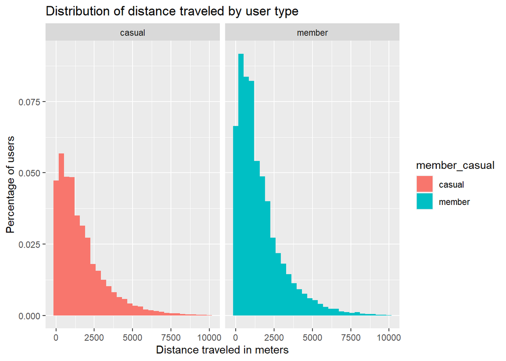

```r
tripdata %>%
  drop_na(member_casual, distance_traveled) %>%
  filter(distance_traveled > 0, distance_traveled < 10000) %>%
  ggplot() +
    geom_histogram(aes(x=distance_traveled, y = stat(count / sum(count)), fill=member_casual)) +
    facet_wrap(~member_casual) +
    ylab("Percentage of users") +
    xlab("Distance traveled in meters") +
    labs(title="Distribution of distance traveled by user type")
```

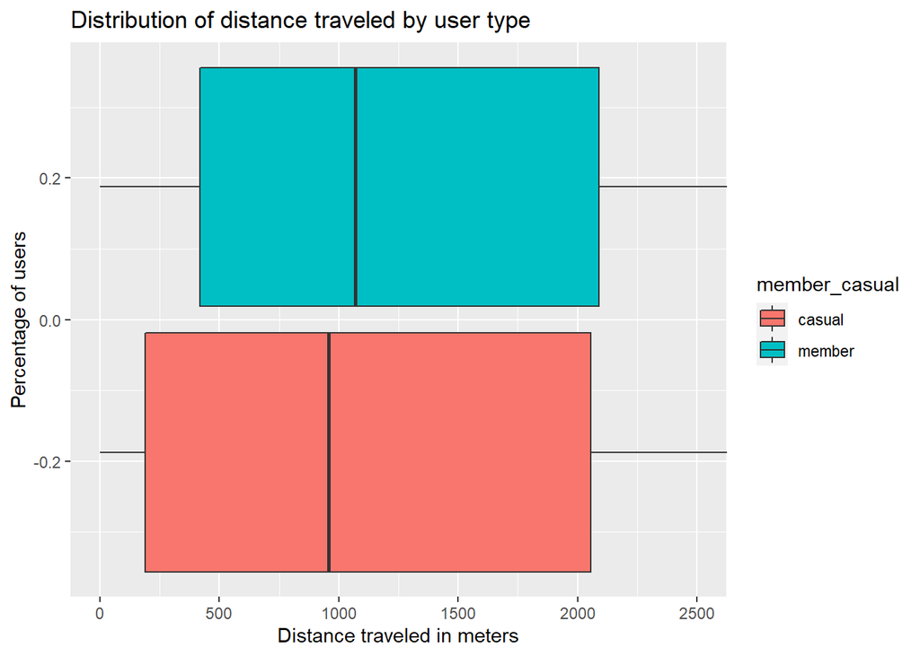

```r
tripdata %>%
  drop_na(member_casual, distance_traveled) %>%
  ggplot() +
    geom_boxplot(aes(distance_traveled, fill=member_casual)) +
    coord_cartesian(xlim=c(0, 2500)) +
    ylab("Percentage of users") +
    xlab("Distance traveled in meters") +
    labs(title="Distribution of distance traveled by user type")
```

The average `casual` and `member` users travel about the same distance, however, the `member` users’ shorter trips are longer than the `casual` users.

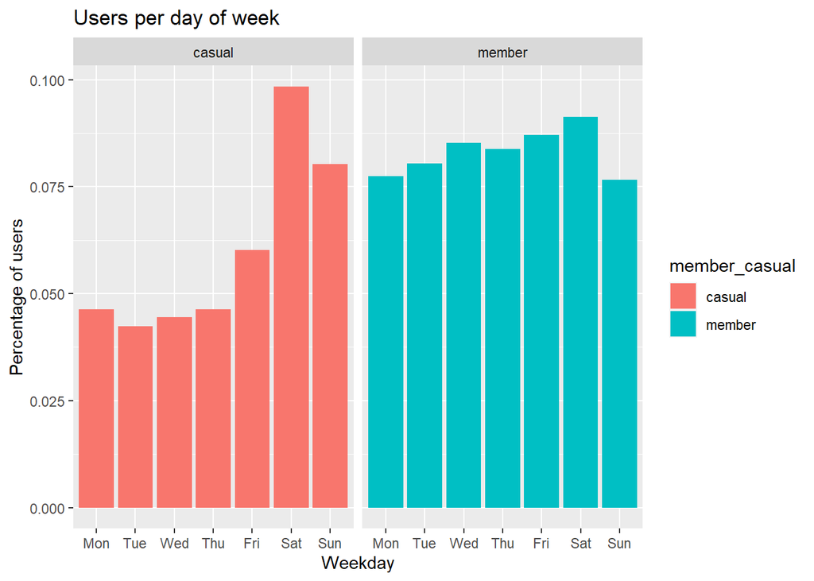

```r
tripdata %>%
  mutate(weekday = weekdays(started_at, abbreviate = TRUE)) %>%
  mutate(weekday_sorted = factor(weekday, levels=c("Mon", "Tue", "Wed", "Thu", "Fri", "Sat", "Sun"))) %>%
  drop_na(member_casual, weekday_sorted) %>%
  ggplot() +
    geom_bar(aes(weekday_sorted, y = stat(count / sum(count)), fill=member_casual)) +
    facet_wrap(~member_casual) +
    xlab("Weekday") +
    ylab("Percentage of users") +
    labs(title="Users per day of week")
```

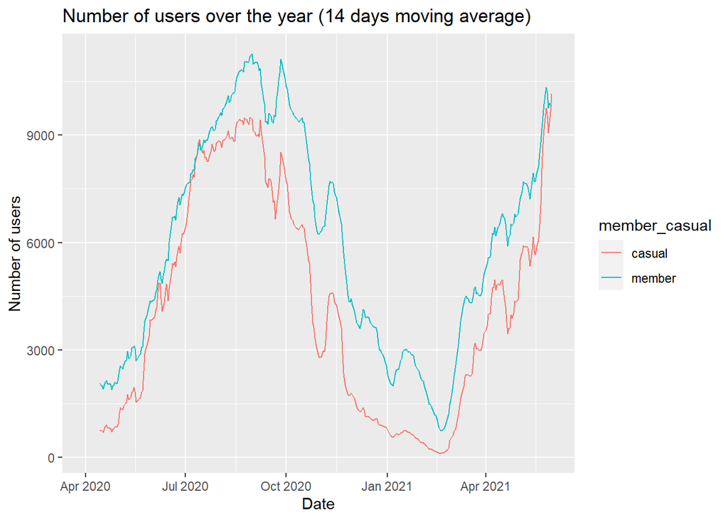

```r
tripdata %>%
  mutate(year = year(started_at),
         month = month(started_at),
         day = day(started_at),
         date = date(started_at)) %>%
  drop_na(member_casual, date) %>%
  group_by(date, member_casual) %>%
  arrange(date) %>%
  summarize(number_users = n()) %>%
  ggplot() +
    geom_ma(aes(date, number_users, color=member_casual), n=14, linetype="solid") +
    xlab("Date") +
    ylab("Number of users") +
    labs(title="Number of users over the year (14 days moving average)")
```

This is a very difficult graph to analyse for the simple fact that this is not a normal year as the world was affected by COVID-19 and COVID-19 also has trends. However, we can clearly see a trend in users over the year so that in the summer there are more users than in the rest of year.

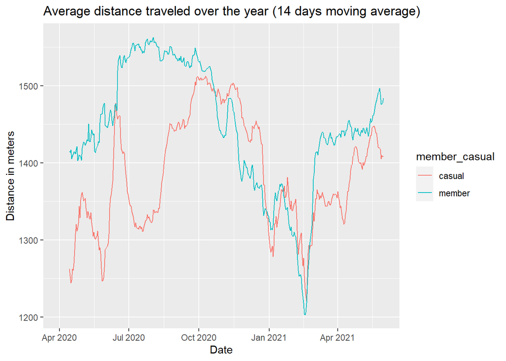

```r
tripdata %>%
  mutate(year = year(started_at),
         month = month(started_at),
         day = day(started_at),
         date = date(started_at)) %>%
  drop_na(member_casual, date) %>%
  group_by(date, member_casual) %>%
  arrange(date) %>%
  summarize(average_duration = mean(distance_traveled)) %>%
  ggplot() +
    geom_ma(aes(date, average_duration, color=member_casual), n=14, linetype="solid") +
    xlab("Date") +
    ylab("Distance in meters") +
    labs(title="Average distance traveled over the year (14 days moving average)")
```